# hec

[figure not shown]

**HERANÇA EXTRA-CROMOSSÔMICA**

Prof. Saulo Chaves

ESALQ / USP - Departamento de Genética

LGN 215 - Genética

## Anteriormente em LGN0215

A genética é o estudo da variação hereditária, a qual está intimamente relacionada à reprodução sexuada (geração de gametas via meiose, fertilização, etc.)

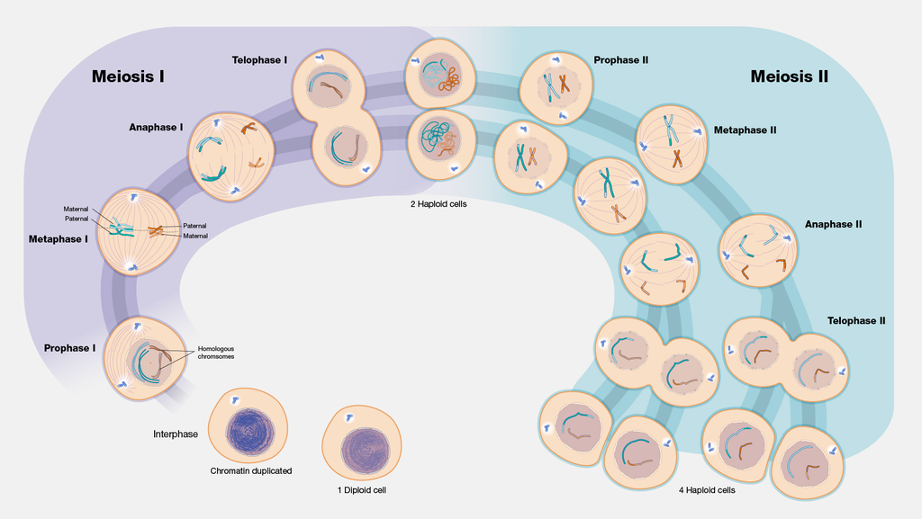

[National Human Genome Research Institute](https://www.genome.gov/genetics-glossary/Meiosis)

## Anteriormente em LGN0215

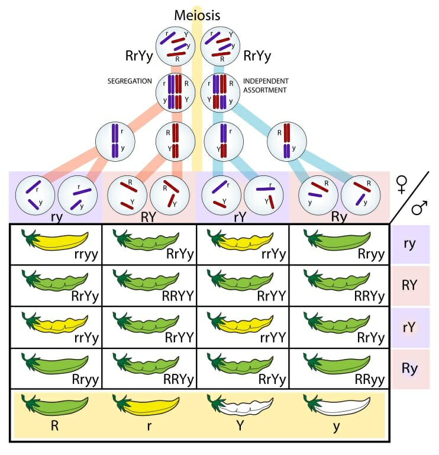

[Gabe Buckley](https://biologydictionary.net/law-of-independent-assortment/)

## Anteriormente em LGN0215

Mutações são mecanismos aleatórios geradores de variação genética. “A mutação gera novas cartas, a recombinação as embaralha e distribui”

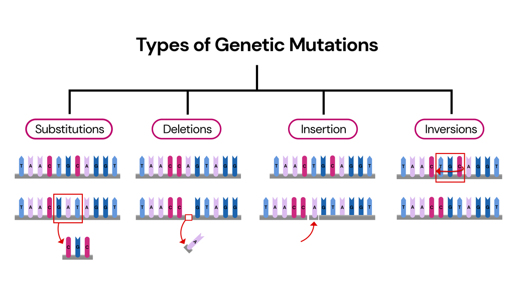

[XCODE](https://www.xcode.life/genetics/what-is-the-ultimate-source-of-genetic-variation/)

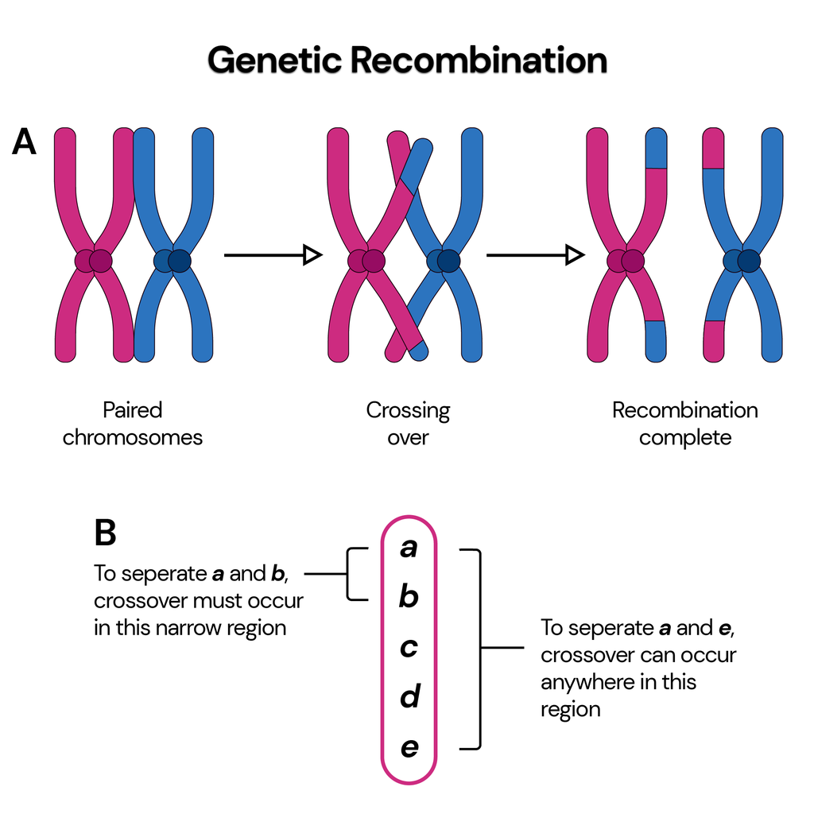

[XCODE](https://www.xcode.life/genetics/what-is-the-ultimate-source-of-genetic-variation/)

## Conteúdo de hoje

1. Herança extra-cromossômica
   - DNA mitocondrial e cloroplastidial
2. Efeito materno
   - Relação com a herança extra-cromossômica
3. Uso no melhoramento
   - Macho-esterilidade genético-citoplasmática

# Herança extra-cromossômica

## DNA extra-cromossômico

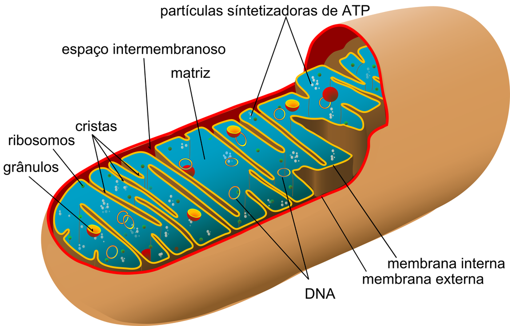

[Felipe Fontoura/Wikimedias](https://pt.wikipedia.org/wiki/Mitoc%C3%B4ndria)

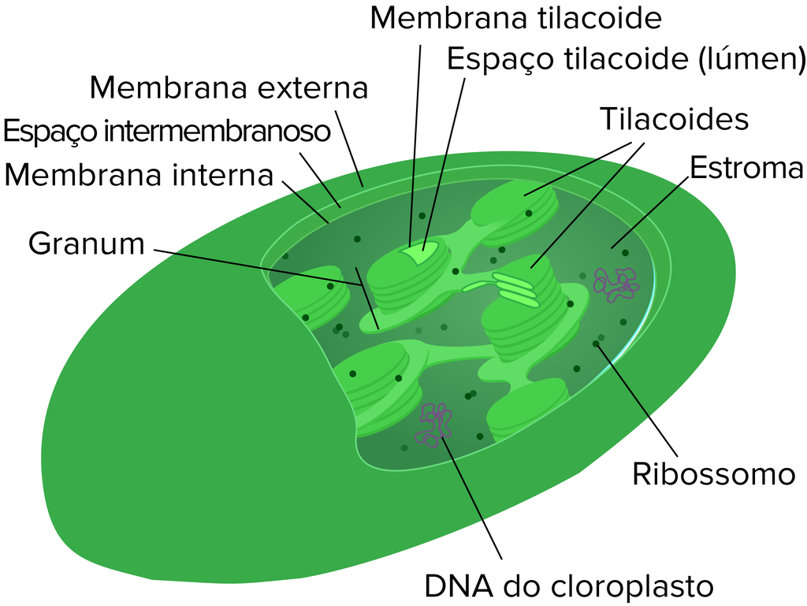

[Khan Academy](https://cdn.kastatic.org/ka-perseus-images/770f75d47d05171086632cb4b3d64267f4da457a.png)

## DNA extra-cromossômico

- Herdados independentemente do genoma nuclear
- Relacionados principalmente às funções internas das organelas
  - Mitocôndria: produção de energia
  - Cloroplasto: fotossíntese
- Ambas ainda são dependentes de genes nucleares (ver teoria da endossimbiose)
- Muitas cópias de DNA circular, organizados ou não em nucleóides

## DNA extra-cromossômico

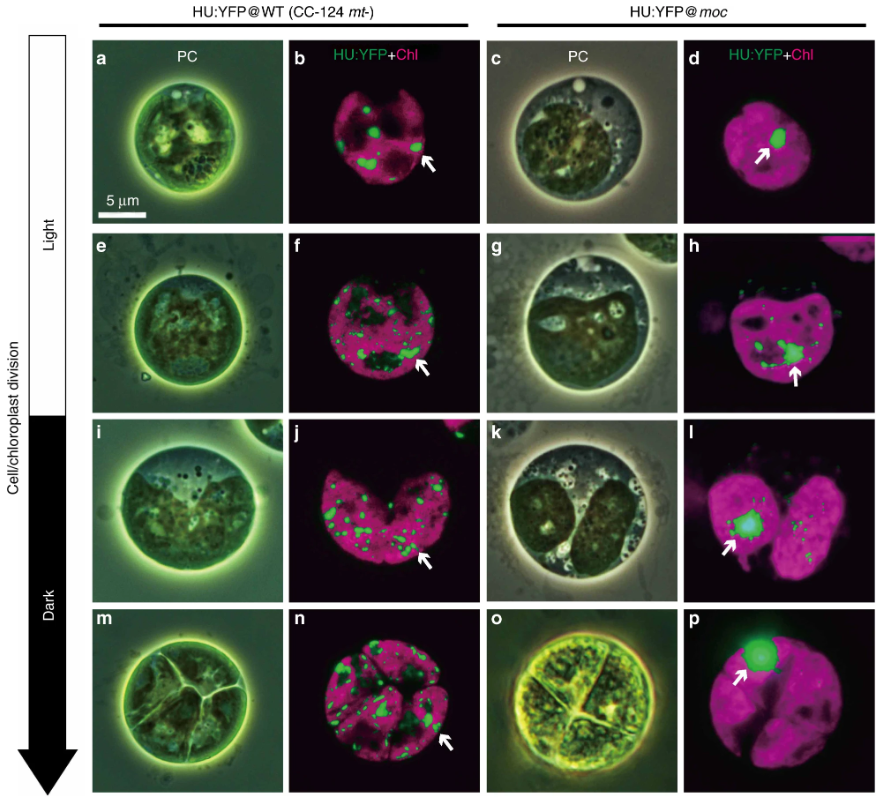

[Kamimura et al. (2018)](https://www.nature.com/articles/s42003-018-0055-1)

## DNA extra-cromossômico

**DNA circular, semelhante ao de bactérias**

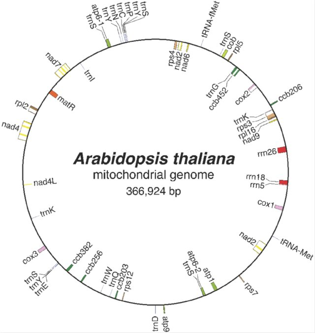

[Cincu (2014)](https://www.researchgate.net/publication/279828478_Regulation_of_mitochondrial_gene_copy_number_in_plants_and_the_influence_of_impaired_chloroplast_function_on_mitochondrial_motility)

mtDNA

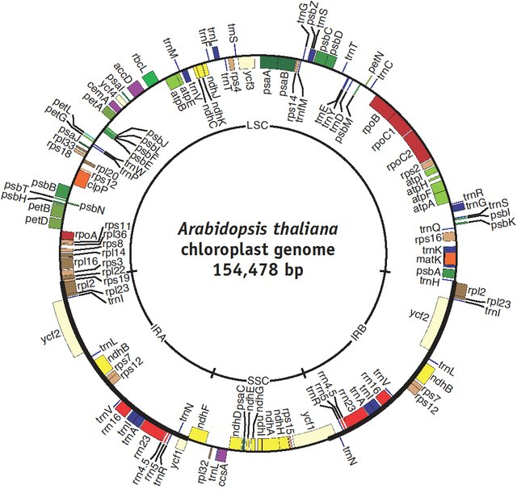

[Cincu (2014)](https://www.researchgate.net/publication/279828478_Regulation_of_mitochondrial_gene_copy_number_in_plants_and_the_influence_of_impaired_chloroplast_function_on_mitochondrial_motility)

cpDNA

## Herança extra-cromossômica

O DNA de organelas é herdado de um único genitor. Comumemente, a herança é materna

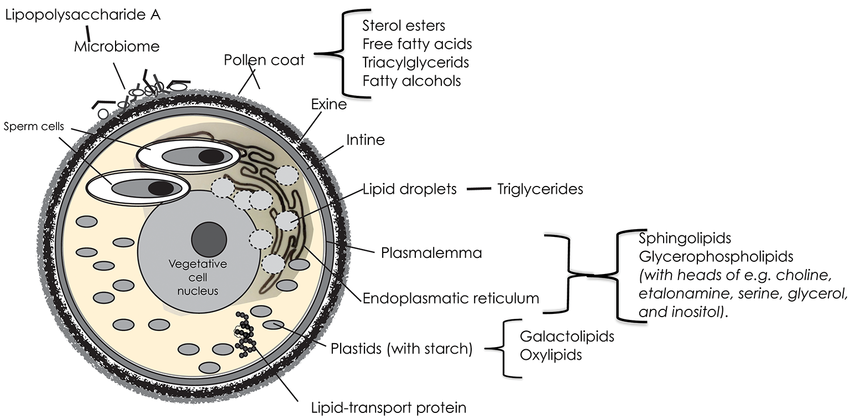

[Dahl (2018)](https://www.frontiersin.org/journals/immunology/articles/10.3389/fimmu.2018.02816/full)

## Herança extra-cromossômica

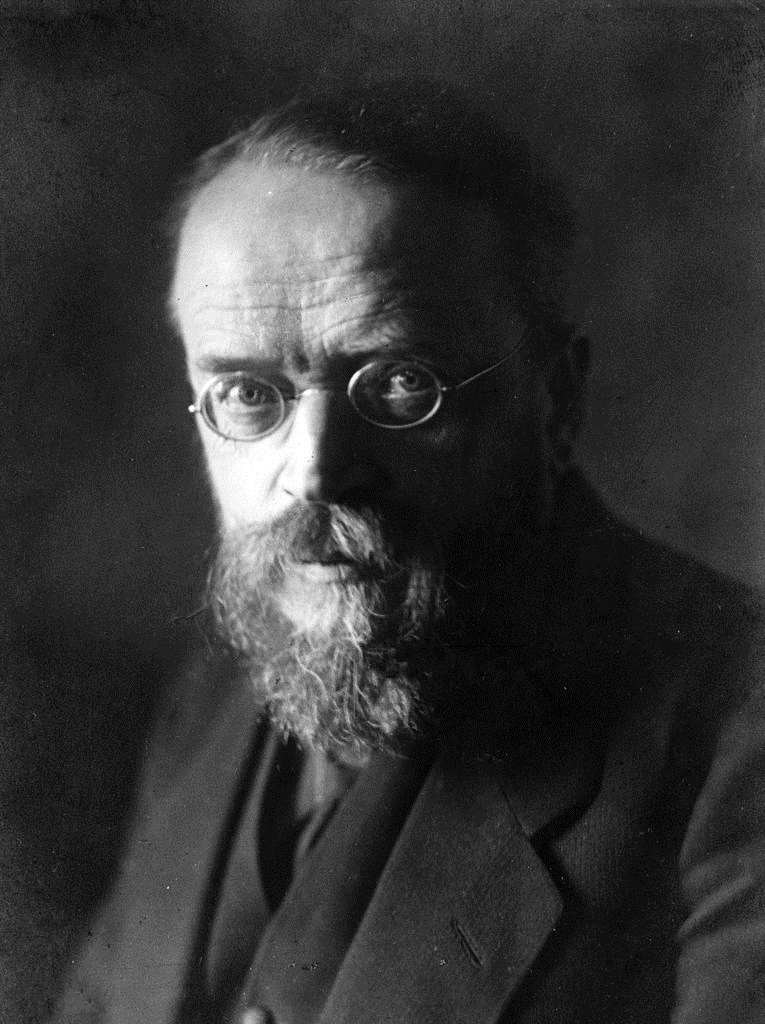

[Mondadori Portfolio](https://www.gettyimages.co.uk/detail/news-photo/portrait-of-the-german-botanist-and-geneticist-carl-correns-news-photo/141551139)

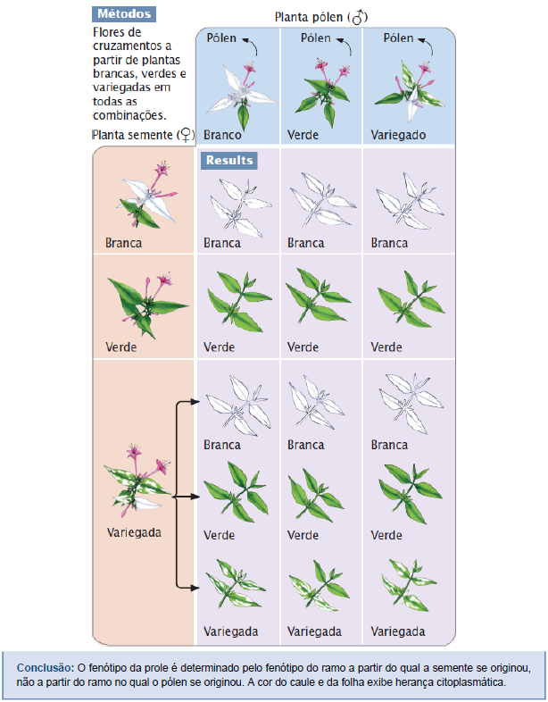

Pierce (2016)

## Herança extra-cromossômica

- Cruzamentos recíprocos podem gerar resultados diferentes
- Dependente do genótipo de um dos pais (herança geralmente materna)
- No experimento de Correns: dependente do ramo
  - A variação fenotípica pode ocorrer dentro de uma mesma família
- Aleatoriedade: segregação citoplasmática
  - Relacionada à multiplicação de organelas e divisão aleatória na divisão celular

## Herança extra-cromossômica

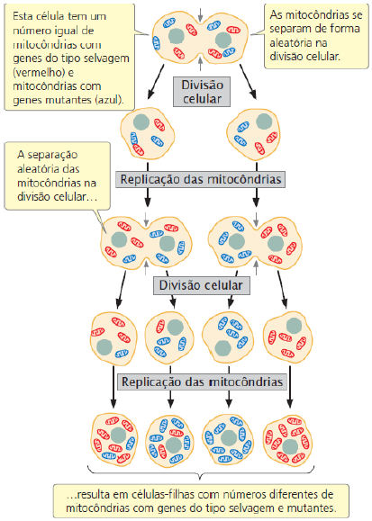

Pierce (2016)

[figure not shown]

## Herança extra-cromossômica

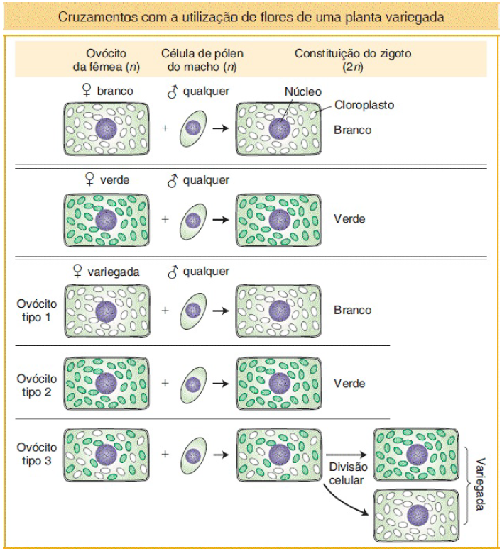

Griffiths et al. (2016)

# Efeito materno

## Efeito materno

Na herança citoplasmática, os genes para uma característica são herdados apenas de um genitor, em geral da mãe. No efeito genético materno, os genes são herdados de ambos os genitores, mas o fenótipo dos descendentes não é determinado pelo seu próprio genótipo, mas pelo de sua mãe

- Transmissão direta de alelos maternais (nucleares)
- Ambiente preparado (ou provido) pela mãe para o desenvolvimento da progênie
  - Genes nucleares maternos influenciam as condições citoplasmáticas do óvulo
  - Proteínas e outros produtos gênicos

## Efeito materno

A segregação de fenótipos com efeito materno é percebida uma ou duas gerações após aquela em que deveria ter ocorrido

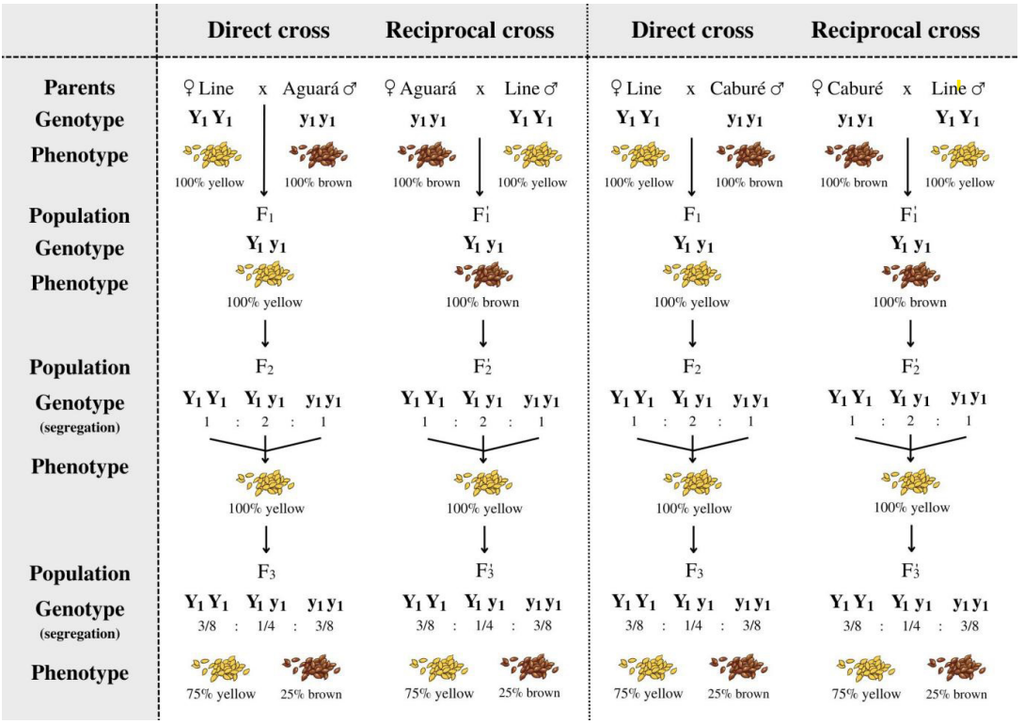

[Fioreze et al. (2023)](https://www.scielo.br/j/cbab/a/xVmwRWVYccnhFNWqnFV76nS/?format=pdf&lang=en)

## Efeito materno

- Fenômeno diferente da herança extra-cromossômica
- Pontos de confusão:
  - O fenótipo da progênie é determinado pela mãe
  - É identificado em cruzamentos recíprocos
- Principais diferenças:
  - A herança é determinada por genes nucleares
  - A herança é mendeliana (identificada uma ou duas gerações afrente)

# Uso no melhoramento

## Macho-esterilidade citoplasmática

- Plantas possuem o aparelho masculino normal, mas não produzem pólens viáveis
  - Não há autofecundação
  - Dispensa a emasculação
- Diferentes mecanismos
  - Genes mitocondriais aberrantes
  - Interação com genes nucleares

## Macho-esterilidade citoplasmática

[figure not shown]

## Macho-esterilidade citoplasmática

**Importância**: produção de híbridos

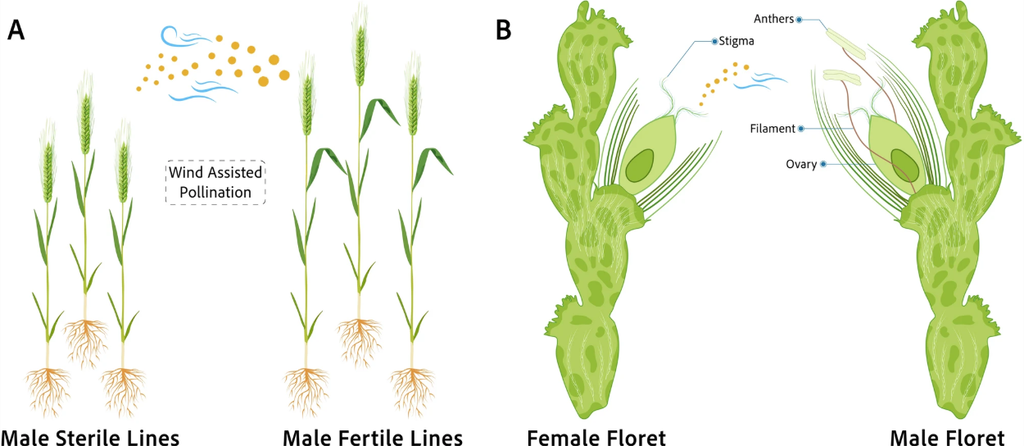

[Abdullah et al. (2025)](https://thericejournal.springeropen.com/articles/10.1186/s12284-025-00807-2)

## Macho-esterilidade citoplasmática

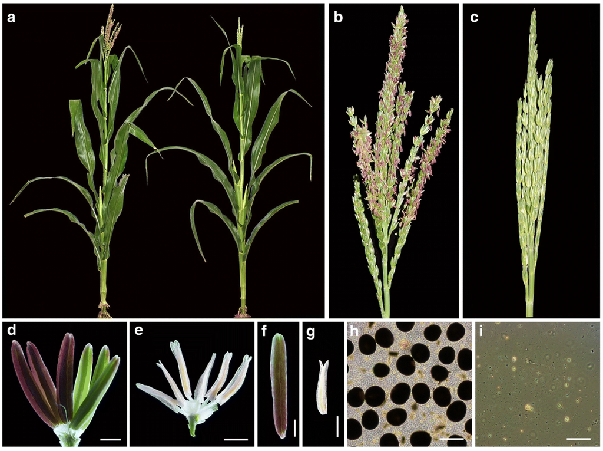

[Zhang et al. (2018)](https://bmcplantbiol.biomedcentral.com/articles/10.1186/s12870-018-1543-7)

## Macho-esterilidade citoplasmática

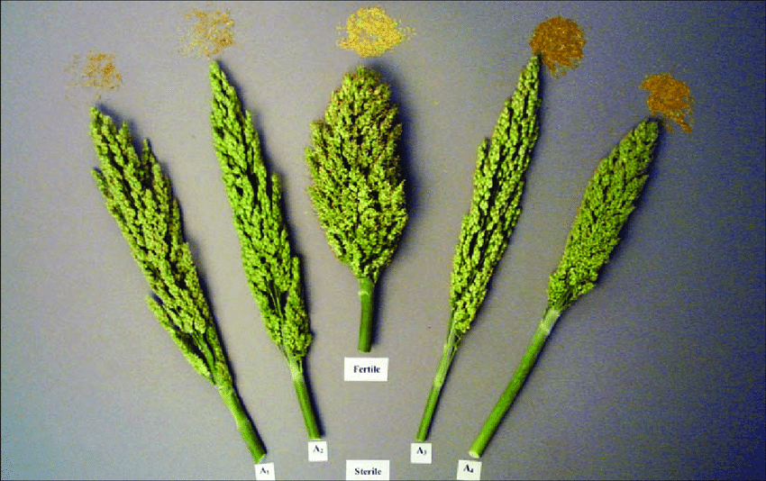

[Are et al.](https://www.researchgate.net/publication/267937762_Alternative_cytoplasmic_male_sterility_systems_in_sorghum_and_their_utilization)

## Macho-esterilidade citoplasmática

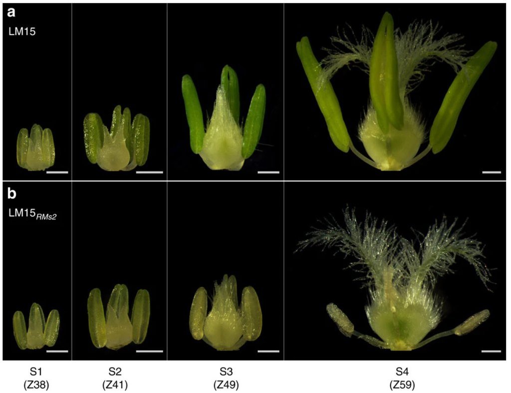

[Ni et al. (2017)](https://www.nature.com/articles/ncomms15121)

## Macho-esterilidade citoplasmática

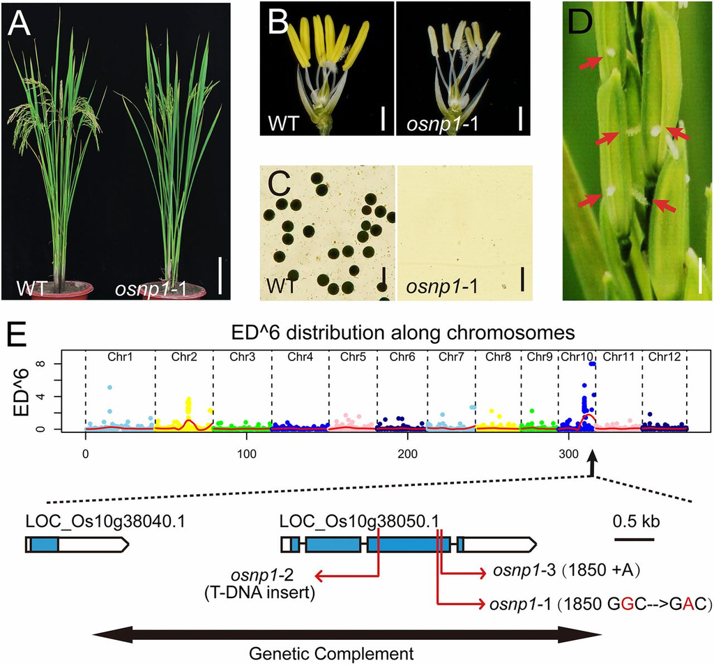

[Chang et al. (2016)](https://www.pnas.org/doi/10.1073/pnas.1613792113)

## Macho-esterilidade citoplasmática

[video not shown]

## Efeito materno genético

**Melhoramento animal**: desenvolvimento inicial

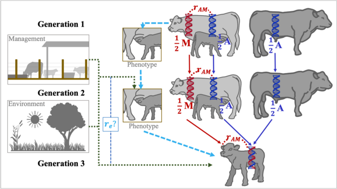

[Javier et al. (2024)](https://link.springer.com/article/10.1007/s11250-024-04142-4)

# Apanhado geral

## Vimos hoje

A herança extra-cromossômica está relacionada com os genes presentes em organelas como mitocôndrias e cloroplastos.

[figure not shown]

[Scitable](https://www.nature.com/scitable/content/inheritance-of-cytoplasmic-and-nuclear-genes-14665120/)

## Vimos hoje

Efeitos genéticos maternos ocorrem quando genes expressos no genoma da mãe afetam o fenótipo da prole.

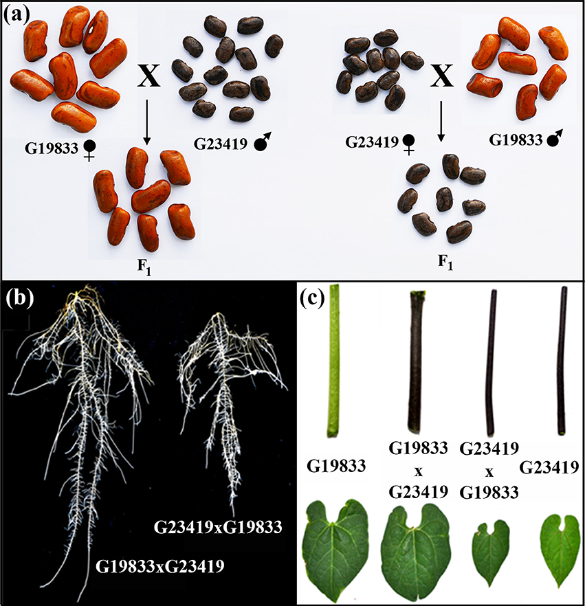

## Material de apoio

- GRIFFITHS, A. J. F., WESSLER, S. R., CARROLL, S. B., & DOEBLEY, J. (2016). Capítulo 3: Distribuição independente de genes. Introdução à Genética.
- RAMALHO, M. A. P., SANTOS, J. B., & PINTO, C. A. B. P. (2004). Capítulo 16: Efeito materno e herança extra-cromossômica. Genética Na Agropecuária.
- [De onde vêm as células (eucariotos)](https://www.youtube.com/watch?v=vSpsk4F3muU)
- [Desenvolvimento de híbridos de arroz](https://www.youtube.com/watch?v=YmDIORf2wJc)